# Presentation

Alex Tryforos

12/2/2019

# Introduction

Concrete is the most important material in civil engineering. Consequently, the strength of concrete is highly important to its performance. Concrete compressive strength is a highly nonlinear function of age and ingredients. These ingredients include cement, blast furnace slag, fly ash, water, superplasticizer, coarse aggregate, and fine aggregate.  
I will be using these ingredients and the age of the concrete to predict its strength.

# Data

Given is the variable name, variable type, the measurement unit and a brief description. The order of this listing corresponds to the order of numerals along the rows of the database.  
**Name** – Data Type – Measurement – Description  
**Cement** (component 1) – quantitative – kg in a m3 mixture – Input Variable  
**Blast Furnace Slag** (component 2) – quantitative – kg in a m3 mixture – Input Variable  
**Fly Ash** (component 3) – quantitative – kg in a m3 mixture – Input Variable  
**Water** (component 4) – quantitative – kg in a m3 mixture – Input Variable  
**Superplasticizer** (component 5) – quantitative – kg in a m3 mixture – Input Variable  
**Coarse Aggregate** (component 6) – quantitative – kg in a m3 mixture – Input Variable  
**Fine Aggregate** (component 7) – quantitative – kg in a m3 mixture – Input Variable  
**Age** – quantitative – Day (1~365) – Input Variable  
**Concrete compressive strength** – quantitative – MPa – Output Variable  
Data has 1030 observations and is sourced from Kaggle.

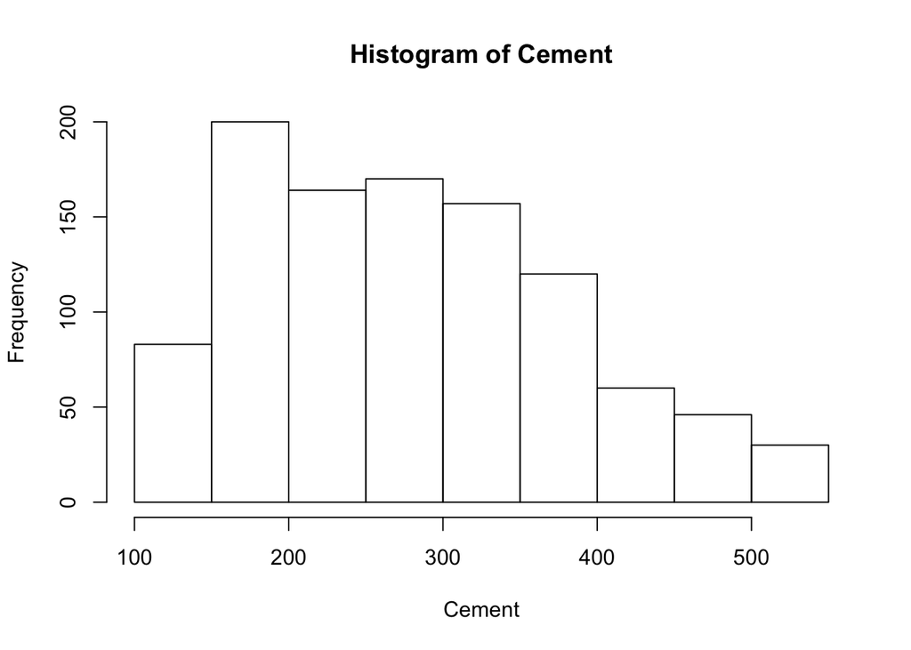

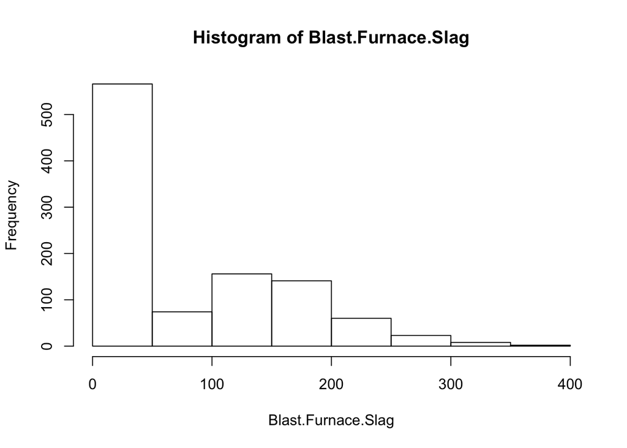

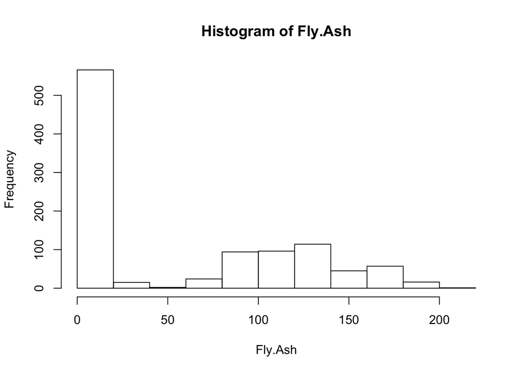

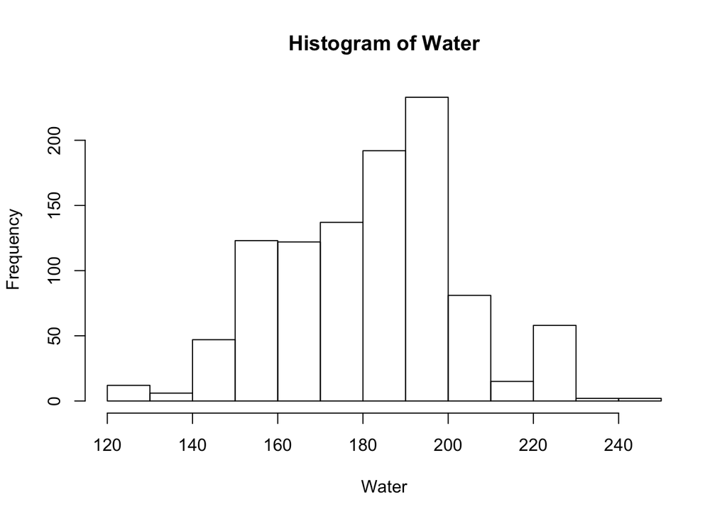

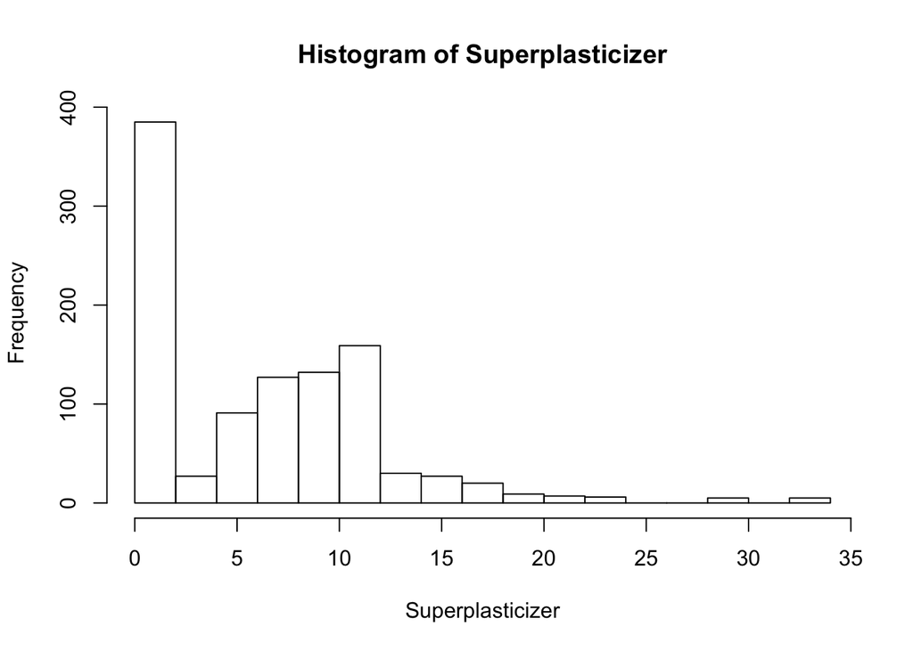

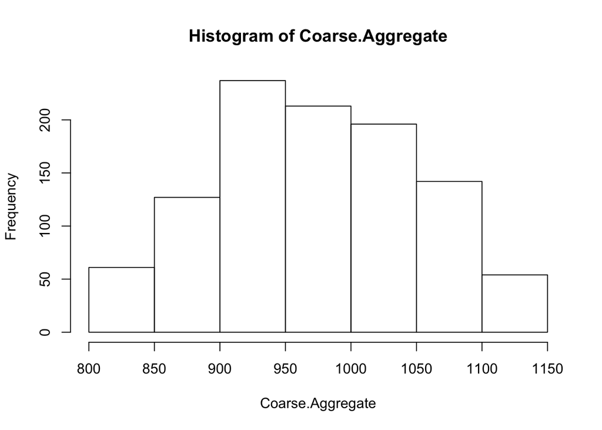

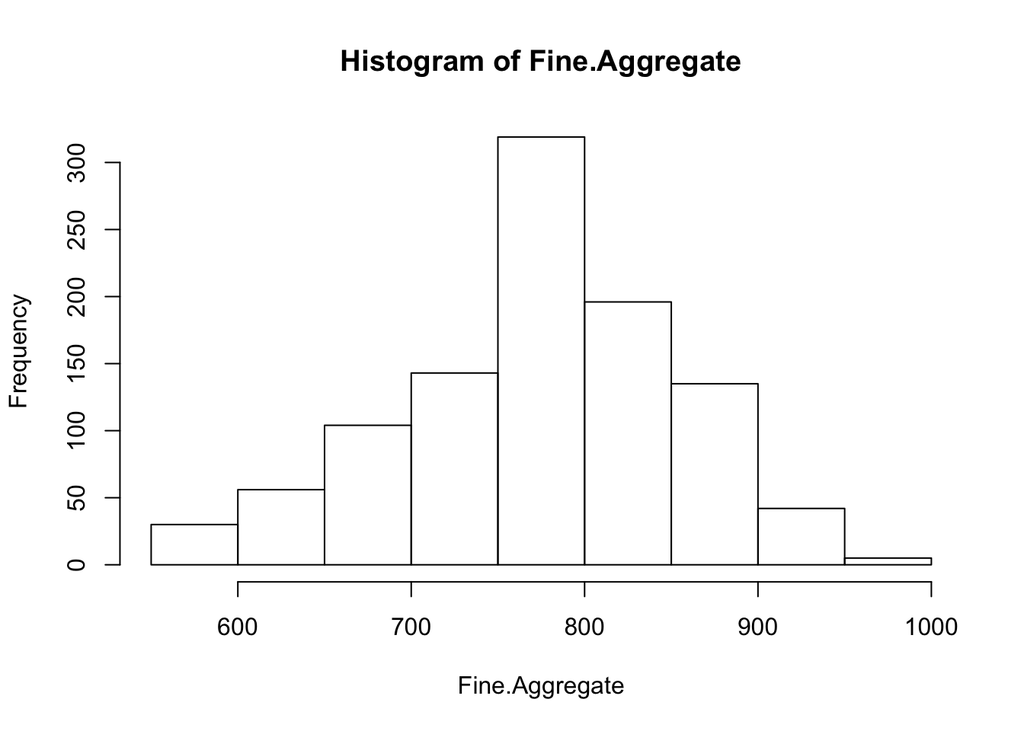

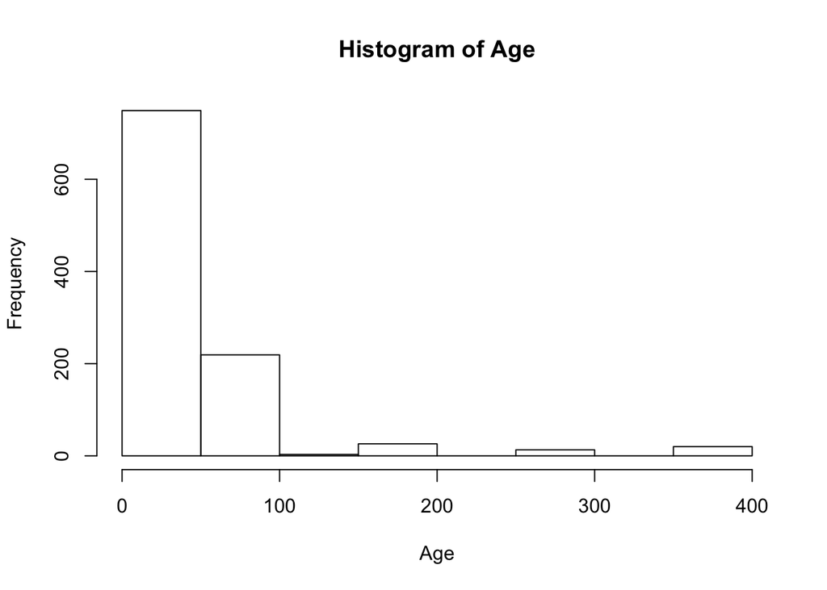

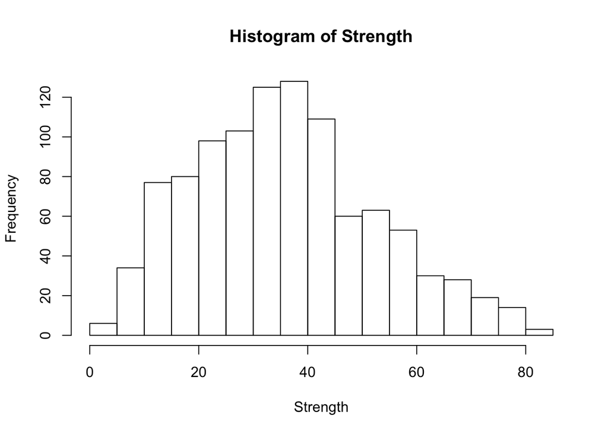

```r
library(neuralnet) #neural network package
library(rpart) #decision tree package
#import data
concrete=read.csv("Concrete_Data.csv",header=TRUE)
#Checking Histograms
for (i in 1:9) {
    hist(concrete[,i],main=paste("Histogram of", colnames(concrete)[i]), xlab = paste(colnames(concrete)[i]))
}
```

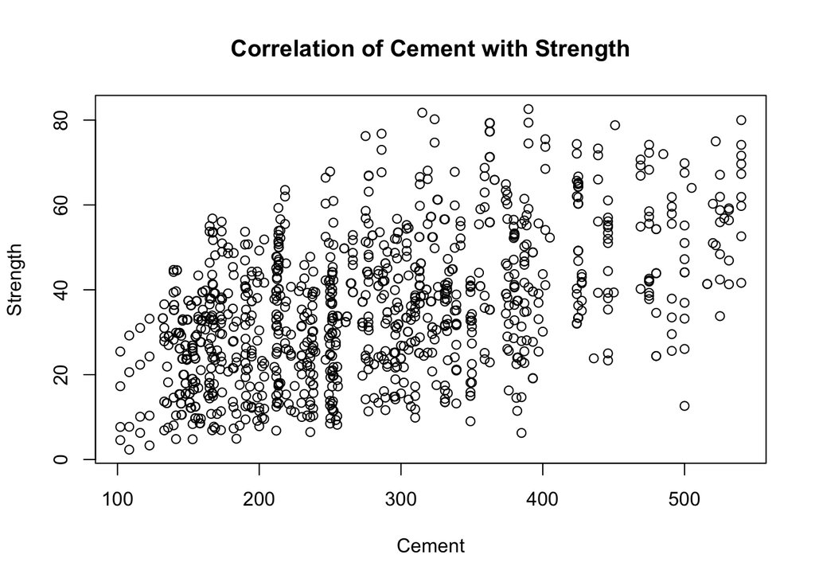

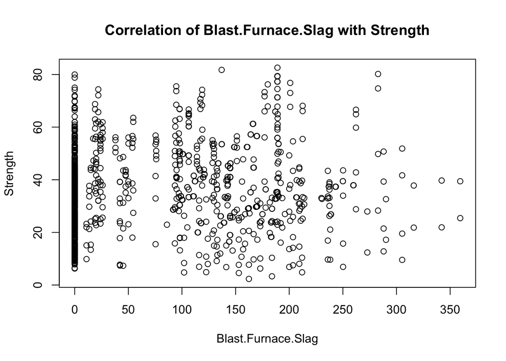

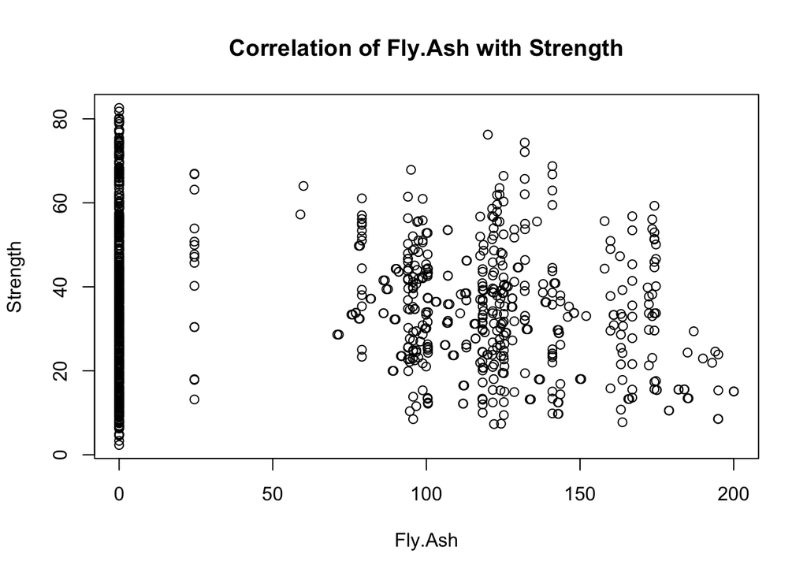

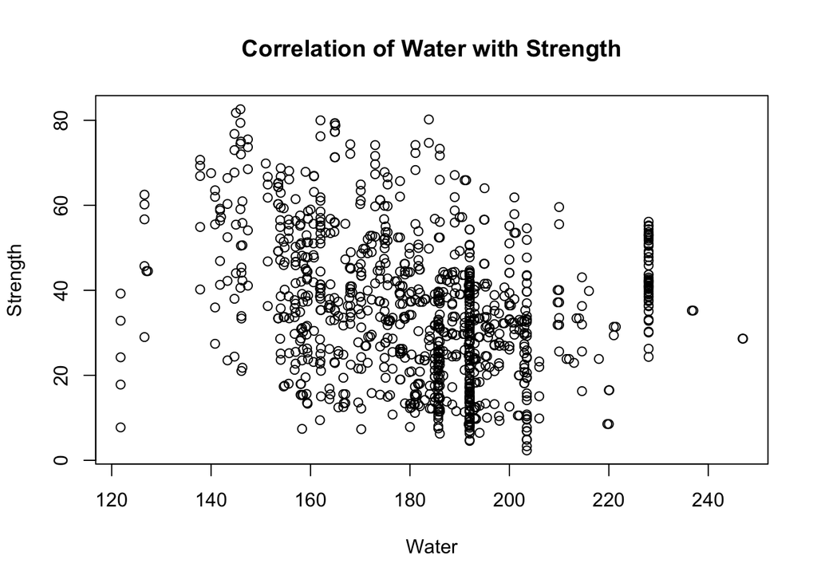

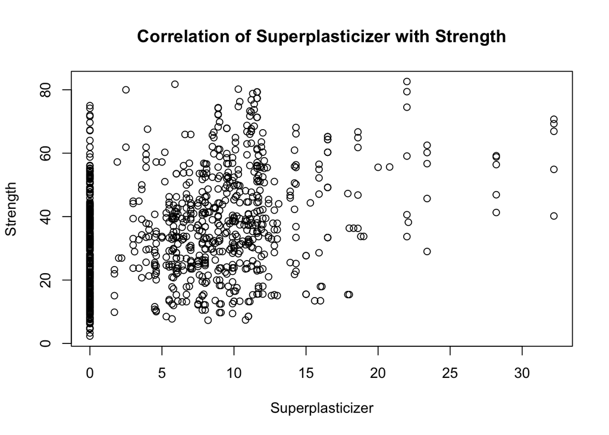

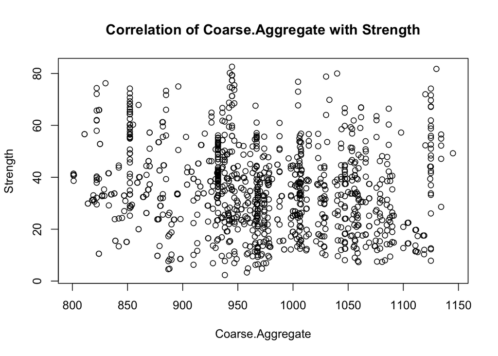

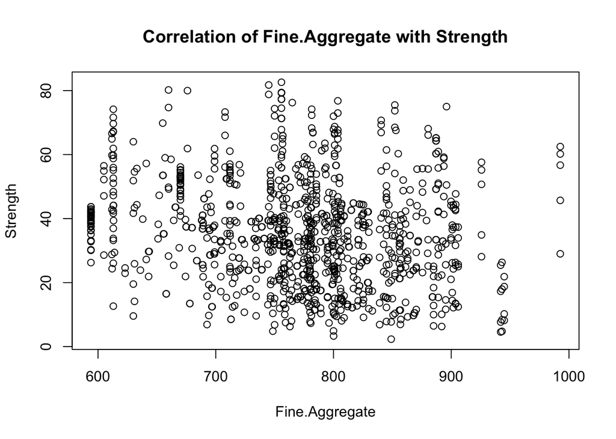

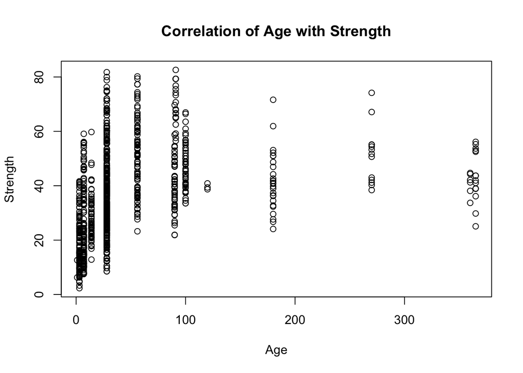

```r
#Checking scatterplots
for (i in 1:8) {
    plot(concrete[,i], concrete$Strength,main=paste("Correlation of", colnames(concrete)[i], "with Strength"),ylab="Strength", xlab = paste(colnames(concrete)[i]))
}
```

```r
summary(concrete)
```

```
##      Cement      Blast.Furnace.Slag    Fly.Ash           Water
##  Min.   :102.0   Min.   :  0.0      Min.   :  0.00   Min.   :121.8
##  1st Qu.:192.4   1st Qu.:  0.0      1st Qu.:  0.00   1st Qu.:164.9
##  Median :272.9   Median : 22.0      Median :  0.00   Median :185.0
##  Mean   :281.2   Mean   : 73.9      Mean   : 54.19   Mean   :181.6
##  3rd Qu.:350.0   3rd Qu.:142.9      3rd Qu.:118.30   3rd Qu.:192.0
##  Max.   :540.0   Max.   :359.4      Max.   :200.10   Max.   :247.0
##  Superplasticizer Coarse.Aggregate Fine.Aggregate       Age
##  Min.   : 0.000   Min.   : 801.0   Min.   :594.0   Min.   :  1.00
##  1st Qu.: 0.000   1st Qu.: 932.0   1st Qu.:731.0   1st Qu.:  7.00
##  Median : 6.400   Median : 968.0   Median :779.5   Median : 28.00
##  Mean   : 6.205   Mean   : 972.9   Mean   :773.6   Mean   : 45.66
##  3rd Qu.:10.200   3rd Qu.:1029.4   3rd Qu.:824.0   3rd Qu.: 56.00
##  Max.   :32.200   Max.   :1145.0   Max.   :992.6   Max.   :365.00
##     Strength
##  Min.   : 2.33
##  1st Qu.:23.71
##  Median :34.45
##  Mean   :35.82
##  3rd Qu.:46.13
##  Max.   :82.60
```

A few things I notice from exploring the data is that strength (the response) appears normally distributed, thus using a squared loss function and predicting the mean is beneficial (also: the gradient descent algorithm prefers a squared loss function since it is differentiable).  
Blast Furnace Slag, Fly Ash, Superplasticizer, and Age all have a large proportion of observations that are at or near 0.  
While the scatterplots are simply observational correlation between each predictor and the response, thus **no** interaction is being considered, Fly Ash & Water appear to be negatively correlated with strength. Additionally, cement content seems to be positively correlated with strength.

# Goal

Use an ensemble of neural networks to predict strength of concrete.  
Additionally, I will implement some global interpretability models in order to better understand how the neural network is making predictions.  
Esnembling multiple high-variance/low-bias (overfit) models will allow our aggregated model to lower variance while retaining low bias. I will ensemble through bootstrapping and random variable selection.

# Data Processing

I will split the data 80/20 train/test. Additionally, scaled data will allow numerical stability and gradient descent to converge faster.

```r
#rename data for easier use
data=concrete
colnames(data) = c("x1","x2","x3","x4","x5","x6","x7","x8","y")
#train/test split
set.seed(1)
size_train = sample(1:nrow(data), size=nrow(data)*0.8, replace=FALSE)
train = data[size_train,]
test = data[-size_train,]
#scaling train/test to mean 0 and sd 1
train_scale = as.data.frame(scale(train))
test_scale = as.data.frame(scale(test))
```

# Modeling

Each model will be built on a bootstrapped data set (sample with replacement from the original data set). Additionally, we will randomly select 3 out of the 8 possible predictors for each model.

```r
####boot strapped
model_boot = list()
number_of_networks = 7
for (i in 1:number_of_networks) {
set.seed(i)
#create bootstrapped sample
boot = sample(1:nrow(train),nrow(train),replace = TRUE)
#select participating varibles to build nn
var = sample(1:(ncol(train)-1), 3 , replace = FALSE)
#create training set for this iteration including variables chosen from above and the response
train_boot = train_scale[boot,c(var,9)] #column 9 is response
outcome <- "y"
variables <- colnames(train_boot)[-4] #y (response) is the fourth element of vector
f <- as.formula(paste(outcome, paste(variables, collapse = " + "), sep = " ~ "))
model_boot[[i]]=neuralnet::neuralnet(f,data=train_boot,hidden = c(2,2), startweights = NULL, act.fct = 'logistic', stepmax = 1e6, linear.output=TRUE, learningrate = 0.005)}
```

# Predictions

Since our response (strength) is numeric, I will take the average of all predictions from the models as the final prediction. Additionally, I will back-transform to compute the MSE on the unstandardized scale.  
Additionally, we can examine how bagging allows for high variance models to combine predictions to create a more accurate prediction.

```r
#calculate test set predictions for each model
predictions = as.data.frame(matrix(0,ncol = number_of_networks,nrow = nrow(test_scale)))
for (i in 1:number_of_networks) {
  predictions[,i] = predict(model_boot[[i]], newdata = test_scale)
}
#ensemble all predictions together
predictions$final = rowMeans(predictions)
predictions$actual = test_scale$y

#Examining difference between individual model predictions and ensembled predictions
head(predictions[,1:9], 10)
```

```
##            V1          V2         V3         V4         V5         V6
## 1   0.1799553 -0.15087761 -0.4608023  0.3844147  0.5627847  0.4056927
## 2   0.1799553 -0.15087761 -0.4608023  0.3844147  0.5627847  0.4182897
## 3   0.3885584 -0.06496072 -0.4608023  0.6862148  0.5627847 -0.2499912
## 4  -0.3946906 -0.80124989 -0.4608023 -0.9353382 -0.4496583  0.2397666
## 5   0.0343532 -0.19034514 -0.4608023  0.4069569  0.5627847  0.4182897
## 6   0.2622774 -0.08322624 -0.4608023  0.4936879  0.5627847  0.2235912
## 7   0.3885584 -0.06496072 -0.4608023  0.6862148  0.5627847  0.3704123
## 8   0.2622774 -0.08322624 -0.4608023  0.4936879  0.5627847  0.4056927
## 9   0.3313231 -0.06717208 -0.4608023  0.5942901  0.5627847 -0.2499912
## 10 -0.3190492 -0.79991972 -0.4608023 -0.8125468 -0.8123969  0.3888305
##            V7       final    actual
## 1  -0.3666877  0.07921141 0.3074508
## 2  -0.3666877  0.08101098 0.3573611
## 3  -0.3666877  0.07073086 0.2447430
## 4  -0.3671431 -0.45273082 0.2492221
## 5  -0.3666877  0.05779277 1.3229329
## 6  -0.3666877  0.09023214 0.3260072
## 7  -0.3666877  0.15935994 0.4578215
## 8  -0.3666877  0.11624664 0.3637598
## 9  -0.3666877  0.04910637 0.1257262
## 10 -0.3668809 -0.45468076 0.4002327
```

```r
#Back transform to unstandardize
predictions$final_unscaled = predictions$final * sd(test$y) + mean(test$y)
predictions$actual_unscaled = predictions$actual* sd(test$y) + mean(test$y)

#mse
mse=round(sum((predictions$final_unscaled - predictions$actual_unscaled)**2)/nrow(predictions),digits=2)
print(paste("Test set MSE is: ",mse))
```

```
## [1] "Test set MSE is:  137.38"
```

```r
#rmse
rmse=round(sqrt(sum((predictions$final_unscaled - predictions$actual_unscaled)**2)/nrow(predictions)),digits=2)
print(paste("Test set RMSE is: ",rmse))
```

```
## [1] "Test set RMSE is:  11.72"
```

```r
#mae
mae=round(sum(abs(predictions$final_unscaled - predictions$actual_unscaled))/nrow(predictions),digits=2)
print(paste("Test set MAE is: ",mae))
```

```
## [1] "Test set MAE is:  9.58"
```

# Surrogate Model

A neural network is “black box” in the sense that while it can approximate any function, studying its structure won’t give you any insights on the structure of the function being approximated. Therefore, interpretting **how** a neural network arrives at predictions can be quite difficult.  
A global surrogate model is an interpretablility model that is trained to approximate the predictions of a black box model. We can draw conclusions about the black box model by interpreting the surrogate model.  
The idea is to fit highly interpretable models (linear regressions, decision trees) using the regular predictors, in our case 8, as inputs. Except we will use the **predictions of the neural network** as the output, rather than the usual response, concrete strength.  
With the R-squared measure, we can easily measure how good our surrogate models are in approximating the black box predictions.  
Since this is a **global** surrogate model, we are trying to interpret how the neural network makes predictions globally, rather than just 1 particular prediction. A **local** surrogate model could be used to explain 1 single prediction.  
$\textit{Note: We have to be aware that we are drawing conclusions about the model and not about the data, since the surrogate model never sees the real outcome.}$

```r
data_sur = test
data_sur$predictions = predictions$final_unscaled
colnames(data_sur) = c(colnames(concrete),"predictions")
#decision tree surrogate
model_sur = rpart(predictions~.-Strength,data=data_sur)
print(paste("The R^2 for the decision tree is: ", round((cor(predict(model_sur,newdata = data_sur),data_sur$prediction)**2),digits=3))) #calculate R^2 for decision tree
```

```
## [1] "The R^2 for the decision tree is:  0.867"
```

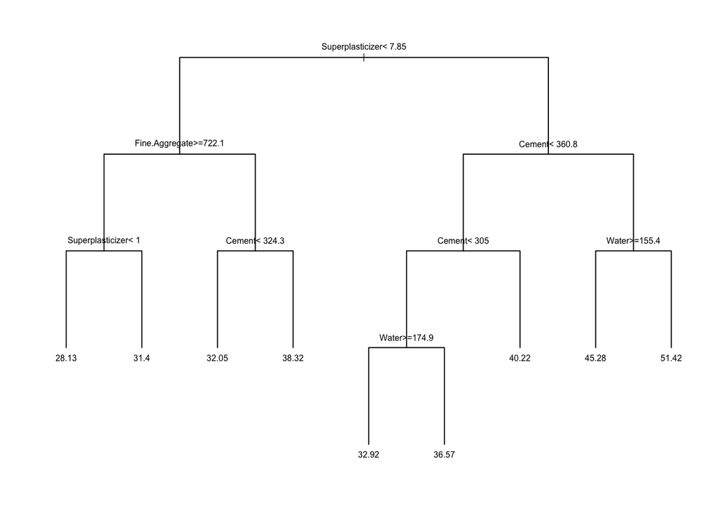

```r
par(mfrow=c(1,1),xpd=NA,cex=0.5)
plot(model_sur,uniform = T)
text(model_sur)
```

```r
#linear regression surrogate
model_sur_lin = lm(predictions~.-Strength,data=data_sur)
summary(model_sur_lin)
```

```
##
## Call:
## lm(formula = predictions ~ . - Strength, data = data_sur)
##
## Residuals:
##     Min      1Q  Median      3Q     Max
## -7.3503 -1.6487 -0.0991  1.7016  6.1818
##
## Coefficients:
##                     Estimate Std. Error t value Pr(>|t|)
## (Intercept)        48.518836  14.141575   3.431 0.000733 ***
## Cement              0.038020   0.004624   8.222 2.66e-14 ***
## Blast.Furnace.Slag  0.019767   0.005338   3.703 0.000277 ***
## Fly.Ash             0.001776   0.006838   0.260 0.795343
## Water              -0.111078   0.023139  -4.800 3.13e-06 ***
## Superplasticizer    0.489997   0.048507  10.102  < 2e-16 ***
## Coarse.Aggregate   -0.001698   0.004788  -0.355 0.723260
## Fine.Aggregate     -0.010676   0.005637  -1.894 0.059706 .
## Age                 0.017307   0.002421   7.150 1.66e-11 ***
## ---
## Signif. codes:  0 '***' 0.001 '**' 0.01 '*' 0.05 '.' 0.1 ' ' 1
##
## Residual standard error: 2.474 on 197 degrees of freedom
## Multiple R-squared:  0.8829, Adjusted R-squared:  0.8782
## F-statistic: 185.7 on 8 and 197 DF,  p-value: < 2.2e-16
```

# Conclusions

Due to computational limitations from training a multilayer neural network, I could not cross-validate nor resample the training/test data. Additionally, the number of layers/units I could use was quite limited. However, in the future (with access to a more powerful computer) I would be interested in cross validating the ensemble to tune hyperparameters such as: number of hidden units, number of hidden layers, learning rate, and momentum while also increasing the number of networks.  
The ensemble of neural networks allows civil engineers to predict concrete strength with reasonably accuracy. Additionally, the surrogate models allow civil engineers to better understand the neural network and present (a proportion) of the model’s predictive process to stakeholders when making decision about concrete. Also, we can see which variables are contributing to an increase or decrease in concrete strength.

# Resources

- Kaggle for Data
- “Interpretable Machine Learning - A Guide for Making Black Box Models Explainable.” by Christoph Molnar